# 06. Maker注文の約定シミュレーション

## 目的

Lead-Lag戦略（BitFlyer→GMO）をMaker注文のみで実行した場合の現実的なパフォーマンスを検証。

## 課題

- 05_lead_lag_strategy.ipynbで、スプレッドコスト0bpsなら+18,339bps、1bpsで-255,318bpsと判明
- 実際にスプレッド0bpsを実現するにはMaker注文のみで取引する必要がある
- Maker注文は約定するとは限らない（約定確率の考慮が必要）

## アプローチ

1. Maker注文の約定条件をモデル化
2. Lead-Lagシグナルに基づくMaker注文戦略をシミュレーション
3. 約定確率、スリッページ、遅延の影響を分析

```python
# 初期設定とライブラリインポート
from etr.auto_import import *
HTML(full_width_display)

import seaborn as sns
from dataclasses import dataclass
from typing import Optional, List, Tuple
from collections import deque
from etr.data.data_loader import load_data
```

```python
# データ読み込み（6日間）
# BitFlyer（リード）とGMO（ラグ）のデータを取得

dates = pd.date_range('2025-12-01', '2025-12-06')
sym = 'BTCJPY'

# GMO Rate（執行対象）
gmo_rates = []
for date in dates:
    df = load_data(date, 'Rate', 'gmo', sym)
    if df is not None and len(df) > 0:
        gmo_rates.append(df)


gmo_rate = pd.concat(gmo_rates, ignore_index=True)
gmo_rate['timestamp'] = pd.to_datetime(gmo_rate['timestamp'])
gmo_rate = gmo_rate.set_index('timestamp').sort_index()

# GMO MarketTrade（約定確認用）
gmo_trades_list = []
for date in dates:
    try:
        df = load_data(date, 'MarketTrade', 'gmo', sym)
        if df is not None and len(df) > 0:
            gmo_trades_list.append(df)
    except:
        pass

gmo_trades = pd.concat(gmo_trades_list, ignore_index=True)
gmo_trades['timestamp'] = pd.to_datetime(gmo_trades['timestamp'])
gmo_trades = gmo_trades.set_index('timestamp').sort_index()

# BitFlyer Rate（シグナル用）
bf_rates = []
for date in dates:
    try:
        df = load_data(date, 'Rate', 'bitflyer', 'FXBTCJPY')
        if df is not None and len(df) > 0:
            bf_rates.append(df)
    except:
        pass

bf_rate = pd.concat(bf_rates, ignore_index=True)
bf_rate['timestamp'] = pd.to_datetime(bf_rate['timestamp'])
bf_rate = bf_rate.set_index('timestamp').sort_index()

print(f"GMO Rate: {len(gmo_rate):,} rows")
print(f"GMO Trades: {len(gmo_trades):,} rows")
print(f"BitFlyer Rate: {len(bf_rate):,} rows")
print(f"期間: {gmo_rate.index.min()} ~ {gmo_rate.index.max()}")
```

[output not shown]

[output not shown]

[output not shown]

[output not shown]

[output not shown]

[output not shown]

[output not shown]

[output not shown]

[output not shown]

[output not shown]

[output not shown]

[output not shown]

[output not shown]

[output not shown]

[output not shown]

[output not shown]

[output not shown]

[output not shown]

```
GMO Rate: 818,552 rows
GMO Trades: 235,293 rows
BitFlyer Rate: 1,618,857 rows
期間: 2025-12-01 00:00:00.212538+00:00 ~ 2025-12-06 23:59:59.914105+00:00
```

## 1. Maker注文の約定モデル

Maker注文が約定する条件：

1. **価格通過**: 反対側の価格が指値価格を通過する
2. **時間優先**: 同じ価格に先に注文がある場合、それが約定するまで待つ

シンプルなモデル：

- Buy Limit @ price → 市場のAsk価格がprice以下になったら約定
- Sell Limit @ price → 市場のBid価格がprice以上になったら約定

```python
# Maker注文シミュレーションクラス

@dataclass
class LimitOrder:
    """指値注文"""
    side: int  # 1=BUY, -1=SELL
    price: float
    size: float
    entry_time: pd.Timestamp
    signal_value: float  # シグナル値（デバッグ用）

@dataclass
class Fill:
    """約定記録"""
    side: int
    price: float
    size: float
    entry_time: pd.Timestamp
    fill_time: pd.Timestamp
    signal_value: float

class MakerOrderSimulatorV2:
    """Maker注文シミュレーター（改良版）"""

    def __init__(self,
                 order_timeout_sec: float = 5.0,
                 position_limit: float = 0.01,
                 order_size: float = 0.001):
        """
        Args:
            order_timeout_sec: 指値注文のタイムアウト（秒）
            position_limit: 最大ポジション（BTC）
            order_size: 1回の注文サイズ（BTC）
        """
        self.order_timeout = pd.Timedelta(seconds=order_timeout_sec)
        self.position_limit = position_limit
        self.order_size = order_size

        # 状態
        self.pending_orders: List[LimitOrder] = []
        self.fills: List[Fill] = []
        self.position = 0.0
        self.pnl = 0.0
        self.avg_entry_price = 0.0

        # 統計
        self.n_orders = 0
        self.n_fills = 0
        self.n_timeouts = 0
        self.n_cancels = 0

    def submit_order(self, side: int, price: float, timestamp: pd.Timestamp, signal_value: float):
        """指値注文を発行"""
        # ポジション制限チェック
        if side == 1 and self.position >= self.position_limit:
            return
        if side == -1 and self.position <= -self.position_limit:
            return

        order = LimitOrder(
            side=side,
            price=price,
            size=self.order_size,
            entry_time=timestamp,
            signal_value=signal_value
        )
        self.pending_orders.append(order)
        self.n_orders += 1

    def update(self, timestamp: pd.Timestamp, bid: float, ask: float):
        """市場価格更新時の処理"""
        # タイムアウト処理
        new_pending = []
        for order in self.pending_orders:
            if timestamp - order.entry_time > self.order_timeout:
                self.n_timeouts += 1
            else:
                new_pending.append(order)
        self.pending_orders = new_pending

        # 約定チェック
        filled_orders = []
        for order in self.pending_orders:
            filled = False
            if order.side == 1 and ask <= order.price:  # Buy filled
                filled = True
            elif order.side == -1 and bid >= order.price:  # Sell filled
                filled = True

            if filled:
                self._process_fill(order, timestamp)
                filled_orders.append(order)

        # 約定した注文を削除
        for order in filled_orders:
            self.pending_orders.remove(order)

    def _process_fill(self, order: LimitOrder, fill_time: pd.Timestamp):
        """約定処理"""
        fill = Fill(
            side=order.side,
            price=order.price,
            size=order.size,
            entry_time=order.entry_time,
            fill_time=fill_time,
            signal_value=order.signal_value
        )
        self.fills.append(fill)
        self.n_fills += 1

        # ポジション・PnL更新
        if order.side == 1:  # Buy
            if self.position < 0:  # Closing short
                close_size = min(order.size, abs(self.position))
                self.pnl += close_size * (self.avg_entry_price - order.price)
                self.position += order.size
                if self.position > 0:
                    self.avg_entry_price = order.price
            else:  # Opening/adding long
                total_cost = self.avg_entry_price * self.position + order.price * order.size
                self.position += order.size
                self.avg_entry_price = total_cost / self.position if self.position > 0 else 0
        else:  # Sell
            if self.position > 0:  # Closing long
                close_size = min(order.size, self.position)
                self.pnl += close_size * (order.price - self.avg_entry_price)
                self.position -= order.size
                if self.position < 0:
                    self.avg_entry_price = order.price
            else:  # Opening/adding short
                total_cost = self.avg_entry_price * abs(self.position) + order.price * order.size
                self.position -= order.size
                self.avg_entry_price = total_cost / abs(self.position) if self.position != 0 else 0

    def cancel_all(self):
        """全注文キャンセル"""
        self.n_cancels += len(self.pending_orders)
        self.pending_orders = []

    def get_stats(self, mid_price: float) -> dict:
        """統計情報取得"""
        # 未実現PnLを加算
        unrealized_pnl = 0
        if self.position > 0:
            unrealized_pnl = self.position * (mid_price - self.avg_entry_price)
        elif self.position < 0:
            unrealized_pnl = abs(self.position) * (self.avg_entry_price - mid_price)

        total_pnl = self.pnl + unrealized_pnl

        return {
            'n_orders': self.n_orders,
            'n_fills': self.n_fills,
            'n_timeouts': self.n_timeouts,
            'n_cancels': self.n_cancels,
            'fill_rate': self.n_fills / self.n_orders if self.n_orders > 0 else 0,
            'realized_pnl': self.pnl,
            'unrealized_pnl': unrealized_pnl,
            'total_pnl': total_pnl,
            'final_position': self.position
        }
```

```python
# データの前処理：1秒リサンプリングとLead-Lagシグナル計算

# GMO Rate: 1秒リサンプリング
gmo_1s = gmo_rate[['best_bid', 'best_ask']].resample('1s').last().dropna()
gmo_1s['mid'] = (gmo_1s['best_bid'] + gmo_1s['best_ask']) / 2

# BitFlyer Rate: 1秒リサンプリング
bf_1s = bf_rate[['best_bid', 'best_ask']].resample('1s').last().dropna()
bf_1s['mid'] = (bf_1s['best_bid'] + bf_1s['best_ask']) / 2

# 共通タイムスタンプに揃える
common_idx = gmo_1s.index.intersection(bf_1s.index)
gmo_1s = gmo_1s.loc[common_idx]
bf_1s = bf_1s.loc[common_idx]

# BitFlyerの累積リターン（過去4秒）= Lead-Lagシグナル
bf_1s['ret'] = bf_1s['mid'].pct_change() * 10000  # bps
bf_1s['cumret_4s'] = bf_1s['ret'].rolling(4).sum()

# シグナルをGMOデータに結合
gmo_1s['bf_signal'] = bf_1s['cumret_4s']
gmo_1s = gmo_1s.dropna()

print(f"分析対象: {len(gmo_1s):,} 秒")
print(f"期間: {gmo_1s.index.min()} ~ {gmo_1s.index.max()}")
```

```
分析対象: 442,888 秒
期間: 2025-12-01 00:00:04+00:00 ~ 2025-12-06 23:59:59+00:00
```

## 2. Lead-Lag戦略のMaker注文シミュレーション

戦略ロジック：

1. BitFlyerの累積リターン（4秒）が閾値を超えたら、GMOでMaker注文
2. シグナル正（上昇予測）→ Best Bidで買い指値
3. シグナル負（下落予測）→ Best Askで売り指値
4. 注文は一定時間後にタイムアウト

```python
# シミュレーション実行関数

def run_maker_simulation(
    data: pd.DataFrame,
    signal_threshold: float = 0.5,
    order_timeout_sec: float = 5.0,
    position_limit: float = 0.01,
    order_size: float = 0.001,
    order_cooldown_sec: int = 1
) -> Tuple[dict, List[Fill]]:
    """
    Maker注文シミュレーション

    Args:
        data: GMOの1秒データ（best_bid, best_ask, mid, bf_signal列必須）
        signal_threshold: シグナル閾値（bps）
        order_timeout_sec: 指値注文のタイムアウト
        position_limit: 最大ポジション
        order_size: 1回の注文サイズ
        order_cooldown_sec: 注文間の最小間隔（秒）
    """
    sim = MakerOrderSimulatorV2(
        order_timeout_sec=order_timeout_sec,
        position_limit=position_limit,
        order_size=order_size
    )

    last_order_time = None
    cooldown = pd.Timedelta(seconds=order_cooldown_sec)

    for timestamp, row in data.iterrows():
        bid = row['best_bid']
        ask = row['best_ask']
        signal = row['bf_signal']

        # 注文状態更新（約定チェック、タイムアウト処理）
        sim.update(timestamp, bid, ask)

        # クールダウンチェック
        if last_order_time is not None and timestamp - last_order_time < cooldown:
            continue

        # シグナルに基づく新規注文
        if abs(signal) >= signal_threshold:
            if signal > 0:  # 上昇予測 → 買い指値（Best Bidで）
                sim.submit_order(1, bid, timestamp, signal)
                last_order_time = timestamp
            else:  # 下落予測 → 売り指値（Best Askで）
                sim.submit_order(-1, ask, timestamp, signal)
                last_order_time = timestamp

    # 最終価格で統計計算
    final_mid = data['mid'].iloc[-1]
    stats = sim.get_stats(final_mid)

    return stats, sim.fills
```

```python
# パラメータグリッドでシミュレーション実行

thresholds = [0.5, 1.0, 2.0, 3.0, 5.0]
timeouts = [3.0, 5.0, 10.0, 30.0]

results = []

for thresh in thresholds:
    for timeout in timeouts:
        stats, fills = run_maker_simulation(
            gmo_1s,
            signal_threshold=thresh,
            order_timeout_sec=timeout,
            position_limit=0.01,
            order_size=0.001,
            order_cooldown_sec=1
        )

        # PnLをbpsに変換（基準価格で正規化）
        base_price = gmo_1s['mid'].iloc[0]
        pnl_bps = stats['total_pnl'] / base_price * 10000

        results.append({
            'threshold': thresh,
            'timeout': timeout,
            **stats,
            'pnl_bps': pnl_bps
        })

results_df = pd.DataFrame(results)
print("=" * 80)
print("Maker注文シミュレーション結果（Lead-Lag戦略）")
print("=" * 80)
print(results_df.to_string())
```

```
================================================================================
Maker注文シミュレーション結果（Lead-Lag戦略）
================================================================================
    threshold  timeout  n_orders  n_fills  n_timeouts  n_cancels  fill_rate   realized_pnl  unrealized_pnl   total_pnl  final_position     pnl_bps
0         0.5      3.0    248200     6777      241420          0   0.027305  -30350.330712       69.144712  -30281.186           0.003  -21.491389
1         0.5      5.0    248061    13504      234554          0   0.054438  -53756.746286      -91.916714  -53848.663          -0.006  -38.217874
2         0.5     10.0    246584    30466      216115          0   0.123552 -121760.987000       -5.867000 -121766.854          -0.002  -86.421277
3         0.5     30.0    239508    75294      164207          0   0.314369 -287056.493240      -78.718760 -287135.212          -0.012 -203.787739
4         1.0      3.0    165004     5130      159871          0   0.031090  -21126.432000        0.000000  -21126.432           0.000  -14.994008
5         1.0      5.0    164626    10143      154480          0   0.061612  -35540.219000       -1.313000  -35541.532          -0.001  -25.224800
6         1.0     10.0    165510    22384      143123          0   0.135243  -86200.139000        0.000000  -86200.139           0.000  -61.178604
7         1.0     30.0    164184    54364      109817          0   0.331116 -213621.457800      -48.921200 -213670.379          -0.010 -151.647731
8         2.0      3.0     76349     3170       73177          0   0.041520   -9845.353855     -155.878145  -10001.232           0.004   -7.098149
9         2.0      5.0     75133     5854       69277          0   0.077915  -19420.006000      -38.636000  -19458.642          -0.002  -13.810332
10        2.0     10.0     74850    12217       62631          0   0.163220  -46652.687000        1.002000  -46651.685           0.001  -33.109981
11        2.0     30.0     75449    27696       47753          0   0.367082 -113562.065843      214.719843 -113347.346           0.010  -80.445722
12        3.0      3.0     34899     1977       32921          0   0.056649   -5361.243695     -209.362305   -5570.606           0.005   -3.953612
13        3.0      5.0     35667     3575       32091          0   0.100233  -12695.056800      -77.137200  -12772.194          -0.003   -9.064777
14        3.0     10.0     34900     7036       27863          0   0.201605  -27211.881000        2.368000  -27209.513           0.002  -19.311338
15        3.0     30.0     35217    14617       20599          0   0.415055  -57108.509000       85.533000  -57022.976           0.007  -40.470771
16        5.0      3.0      9545      898        8647          0   0.094081    1028.061443      108.715557    1136.777           0.006    0.806802
17        5.0      5.0      9229     1448        7781          0   0.156897   -3924.547773      257.471773   -3667.076          -0.008   -2.602624
18        5.0     10.0      9294     2639        6655          0   0.283947  -15705.412000      224.981000  -15480.431          -0.011  -10.986887
19        5.0     30.0      9379     4774        4605          0   0.509009  -15887.780993      633.490993  -15254.290          -0.008  -10.826388
```

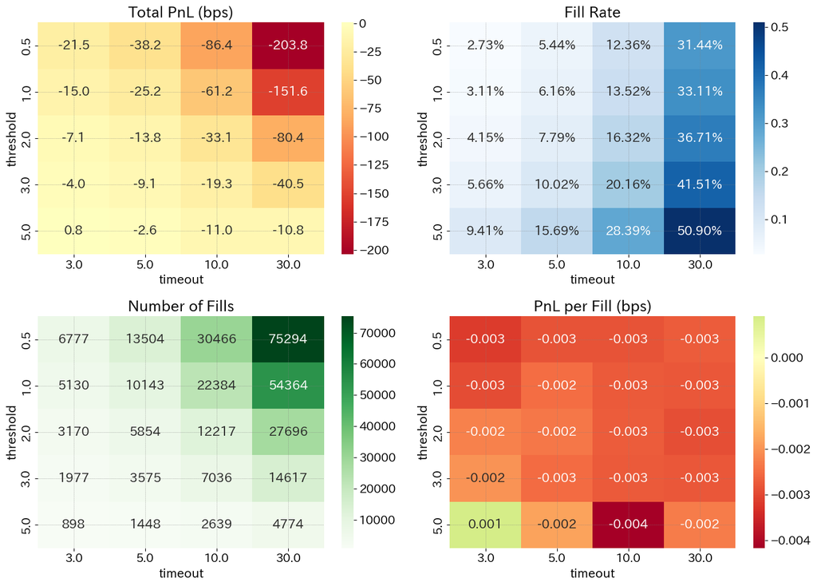

```python
# 結果の可視化

fig, axes = plt.subplots(2, 2, figsize=(14, 10))

# 1. PnL (bps) by threshold and timeout
pivot_pnl = results_df.pivot(index='threshold', columns='timeout', values='pnl_bps')
sns.heatmap(pivot_pnl, annot=True, fmt='.1f', cmap='RdYlGn', center=0, ax=axes[0, 0])
axes[0, 0].set_title('Total PnL (bps)')

# 2. Fill Rate by threshold and timeout
pivot_fill = results_df.pivot(index='threshold', columns='timeout', values='fill_rate')
sns.heatmap(pivot_fill, annot=True, fmt='.2%', cmap='Blues', ax=axes[0, 1])
axes[0, 1].set_title('Fill Rate')

# 3. Number of Fills
pivot_fills = results_df.pivot(index='threshold', columns='timeout', values='n_fills')
sns.heatmap(pivot_fills, annot=True, fmt='.0f', cmap='Greens', ax=axes[1, 0])
axes[1, 0].set_title('Number of Fills')

# 4. PnL per Fill (bps)
results_df['pnl_per_fill'] = results_df['pnl_bps'] / results_df['n_fills'].replace(0, np.nan)
pivot_ppf = results_df.pivot(index='threshold', columns='timeout', values='pnl_per_fill')
sns.heatmap(pivot_ppf, annot=True, fmt='.3f', cmap='RdYlGn', center=0, ax=axes[1, 1])
axes[1, 1].set_title('PnL per Fill (bps)')

plt.tight_layout()
plt.show()
```

```python
# ベストパラメータの詳細分析

best_idx = results_df['pnl_bps'].idxmax()
best_params = results_df.loc[best_idx]

print("=" * 60)
print("ベストパラメータ")
print("=" * 60)
print(f"Signal Threshold: {best_params['threshold']} bps")
print(f"Order Timeout: {best_params['timeout']} sec")
print(f"")
print(f"注文数: {best_params['n_orders']:,.0f}")
print(f"約定数: {best_params['n_fills']:,.0f}")
print(f"タイムアウト数: {best_params['n_timeouts']:,.0f}")
print(f"約定率: {best_params['fill_rate']:.2%}")
print(f"")
print(f"Total PnL: {best_params['pnl_bps']:.2f} bps")
print(f"PnL/Fill: {best_params['pnl_per_fill']:.4f} bps")
```

```
============================================================
ベストパラメータ
============================================================
Signal Threshold: 5.0 bps
Order Timeout: 3.0 sec

注文数: 9,545
約定数: 898
タイムアウト数: 8,647
約定率: 9.41%

Total PnL: 0.81 bps
PnL/Fill: 0.0009 bps
```

```python
# ベストパラメータで詳細シミュレーション実行し、約定の分析

best_stats, best_fills = run_maker_simulation(
    gmo_1s,
    signal_threshold=best_params['threshold'],
    order_timeout_sec=best_params['timeout'],
    position_limit=0.01,
    order_size=0.001,
    order_cooldown_sec=1
)

fills_df = pd.DataFrame([{
    'entry_time': f.entry_time,
    'fill_time': f.fill_time,
    'side': f.side,
    'price': f.price,
    'signal': f.signal_value,
    'fill_delay_sec': (f.fill_time - f.entry_time).total_seconds()
} for f in best_fills])

if len(fills_df) > 0:
    print("=" * 60)
    print("約定詳細分析")
    print("=" * 60)
    print(f"約定数: {len(fills_df)}")
    print(f"Buy約定: {(fills_df['side'] == 1).sum()}")
    print(f"Sell約定: {(fills_df['side'] == -1).sum()}")
    print(f"")
    print("約定遅延（秒）:")
    print(fills_df['fill_delay_sec'].describe())
    print(f"")
    print("シグナル強度:")
    print(fills_df['signal'].abs().describe())
else:
    print("約定なし")
```

```
============================================================
約定詳細分析
============================================================
約定数: 898
Buy約定: 452
Sell約定: 446

約定遅延（秒）:
count    898.000000
mean       2.097996
std        0.789689
min        1.000000
25%        1.000000
50%        2.000000
75%        3.000000
max        3.000000
Name: fill_delay_sec, dtype: float64

シグナル強度:
count    898.000000
mean       8.137698
std        3.683075
min        5.002652
25%        5.706161
50%        6.927463
75%        9.246513
max       39.519691
Name: signal, dtype: float64
```

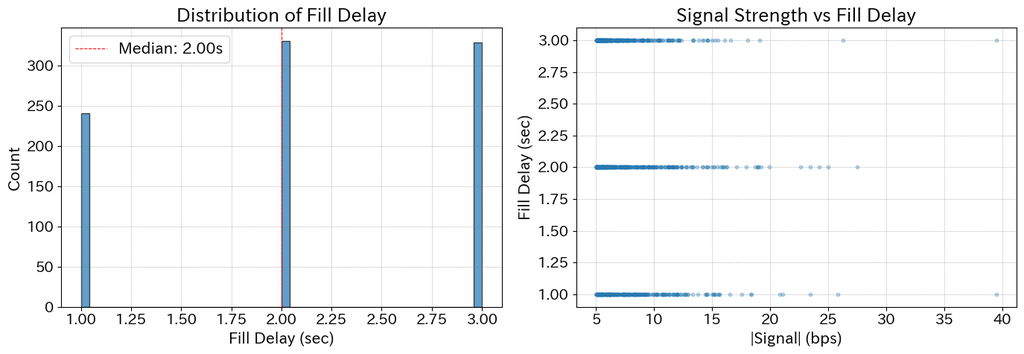

```python
# 約定遅延の分布可視化

if len(fills_df) > 0:
    fig, axes = plt.subplots(1, 2, figsize=(14, 5))

    # 約定遅延のヒストグラム
    axes[0].hist(fills_df['fill_delay_sec'], bins=50, edgecolor='black', alpha=0.7)
    axes[0].set_xlabel('Fill Delay (sec)')
    axes[0].set_ylabel('Count')
    axes[0].set_title('Distribution of Fill Delay')
    axes[0].axvline(fills_df['fill_delay_sec'].median(), color='red', linestyle='--', label=f"Median: {fills_df['fill_delay_sec'].median():.2f}s")
    axes[0].legend()

    # シグナル強度と約定遅延の関係
    axes[1].scatter(fills_df['signal'].abs(), fills_df['fill_delay_sec'], alpha=0.3, s=10)
    axes[1].set_xlabel('|Signal| (bps)')
    axes[1].set_ylabel('Fill Delay (sec)')
    axes[1].set_title('Signal Strength vs Fill Delay')

    plt.tight_layout()
    plt.show()
```

## 3. 約定後のリターン分析

Maker注文が約定した後、予測通りに価格が動いているか検証

```python
# 約定後のリターンを計算

if len(fills_df) > 0:
    # 約定後のリターンを計算（各horizon）
    horizons = [1, 2, 5, 10, 30, 60]  # 秒

    for h in horizons:
        fills_df[f'ret_{h}s'] = np.nan

    for idx, row in fills_df.iterrows():
        fill_time = row['fill_time']

        for h in horizons:
            future_time = fill_time + pd.Timedelta(seconds=h)

            # 約定時の価格
            fill_price = row['price']

            # 将来価格を取得
            future_data = gmo_1s[gmo_1s.index >= future_time]
            if len(future_data) > 0:
                future_mid = future_data['mid'].iloc[0]

                # リターン計算（買いの場合は上昇が利益、売りの場合は下落が利益）
                ret_bps = (future_mid - fill_price) / fill_price * 10000
                if row['side'] == -1:  # Sell position
                    ret_bps = -ret_bps

                fills_df.loc[idx, f'ret_{h}s'] = ret_bps

    # リターン統計
    print("=" * 60)
    print("約定後リターン分析（bps）")
    print("=" * 60)
    for h in horizons:
        col = f'ret_{h}s'
        valid = fills_df[col].dropna()
        if len(valid) > 0:
            mean_ret = valid.mean()
            win_rate = (valid > 0).mean()
            print(f"{h:2d}s後: Mean={mean_ret:+.4f} bps, WinRate={win_rate:.1%}, N={len(valid)}")
```

```
============================================================
約定後リターン分析（bps）
============================================================
 1s後: Mean=-3.1009 bps, WinRate=9.1%, N=898
 2s後: Mean=-3.1964 bps, WinRate=14.3%, N=898
 5s後: Mean=-3.3086 bps, WinRate=22.9%, N=898
10s後: Mean=-3.1782 bps, WinRate=28.3%, N=898
30s後: Mean=-3.2203 bps, WinRate=36.1%, N=898
60s後: Mean=-2.8162 bps, WinRate=41.5%, N=898
```

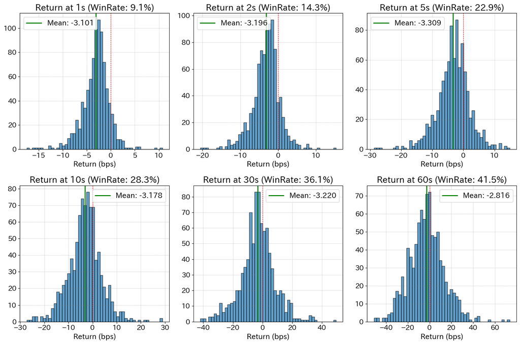

```python
# 約定後リターンの可視化

if len(fills_df) > 0 and 'ret_1s' in fills_df.columns:
    fig, axes = plt.subplots(2, 3, figsize=(15, 10))
    axes = axes.flatten()

    horizons = [1, 2, 5, 10, 30, 60]

    for i, h in enumerate(horizons):
        col = f'ret_{h}s'
        if col in fills_df.columns:
            valid = fills_df[col].dropna()
            if len(valid) > 0:
                axes[i].hist(valid, bins=50, edgecolor='black', alpha=0.7)
                axes[i].axvline(0, color='red', linestyle='--')
                axes[i].axvline(valid.mean(), color='green', linestyle='-', linewidth=2,
                               label=f'Mean: {valid.mean():.3f}')
                axes[i].set_title(f'Return at {h}s (WinRate: {(valid>0).mean():.1%})')
                axes[i].set_xlabel('Return (bps)')
                axes[i].legend()

    plt.tight_layout()
    plt.show()
```

実際の市場では:

1. 指値注文はキューに並ぶ（時間優先）
2. 価格が到達しても、先行注文が約定するまで待つ
3. 部分約定の可能性がある

より保守的なシミュレーションを実装

```python
# 保守的なMaker注文シミュレーター
# 価格が「通過」した場合のみ約定と判定（タッチは不可）

def run_conservative_maker_simulation(
    data: pd.DataFrame,
    signal_threshold: float = 0.5,
    order_timeout_sec: float = 5.0,
    position_limit: float = 0.01,
    order_size: float = 0.001,
    order_cooldown_sec: int = 1,
    price_improvement_bps: float = 0.0  # 価格改善（負=悪化）
) -> Tuple[dict, List]:
    """
    保守的なMaker注文シミュレーション
    - 買い指値: Ask価格が指値を「下回った」場合のみ約定
    - 売り指値: Bid価格が指値を「上回った」場合のみ約定
    """
    orders = []  # (timestamp, side, price, signal)
    fills = []   # (entry_time, fill_time, side, price, signal)

    position = 0.0
    pnl = 0.0
    avg_entry = 0.0

    timeout = pd.Timedelta(seconds=order_timeout_sec)
    cooldown = pd.Timedelta(seconds=order_cooldown_sec)
    last_order_time = None

    n_orders = 0
    n_fills = 0
    n_timeouts = 0

    for timestamp, row in data.iterrows():
        bid = row['best_bid']
        ask = row['best_ask']
        signal = row['bf_signal']
        mid = row['mid']

        # タイムアウト処理
        new_orders = []
        for o in orders:
            if timestamp - o[0] > timeout:
                n_timeouts += 1
            else:
                new_orders.append(o)
        orders = new_orders

        # 約定チェック（保守的: 価格通過のみ）
        filled_orders = []
        for o in orders:
            o_time, o_side, o_price, o_signal = o

            filled = False
            # 買い指値: Ask < 指値 で約定（Ask <= ではなく < ）
            if o_side == 1 and ask < o_price:
                filled = True
            # 売り指値: Bid > 指値 で約定
            elif o_side == -1 and bid > o_price:
                filled = True

            if filled:
                fills.append((o_time, timestamp, o_side, o_price, o_signal))
                filled_orders.append(o)
                n_fills += 1

                # ポジション・PnL更新
                if o_side == 1:  # Buy
                    if position < 0:
                        close_size = min(order_size, abs(position))
                        pnl += close_size * (avg_entry - o_price)
                    position += order_size
                    if position > 0:
                        avg_entry = o_price
                else:  # Sell
                    if position > 0:
                        close_size = min(order_size, position)
                        pnl += close_size * (o_price - avg_entry)
                    position -= order_size
                    if position < 0:
                        avg_entry = o_price

        for o in filled_orders:
            orders.remove(o)

        # 新規注文
        if last_order_time is not None and timestamp - last_order_time < cooldown:
            continue

        if abs(signal) >= signal_threshold:
            # ポジション制限
            if signal > 0 and position < position_limit:
                # 買い指値: Bid + 改善
                price = bid * (1 + price_improvement_bps / 10000)
                orders.append((timestamp, 1, price, signal))
                n_orders += 1
                last_order_time = timestamp
            elif signal < 0 and position > -position_limit:
                # 売り指値: Ask - 改善
                price = ask * (1 - price_improvement_bps / 10000)
                orders.append((timestamp, -1, price, signal))
                n_orders += 1
                last_order_time = timestamp

    # 最終統計
    unrealized = 0
    final_mid = data['mid'].iloc[-1]
    if position > 0:
        unrealized = position * (final_mid - avg_entry)
    elif position < 0:
        unrealized = abs(position) * (avg_entry - final_mid)

    total_pnl = pnl + unrealized
    base_price = data['mid'].iloc[0]
    pnl_bps = total_pnl / base_price * 10000

    return {
        'n_orders': n_orders,
        'n_fills': n_fills,
        'n_timeouts': n_timeouts,
        'fill_rate': n_fills / n_orders if n_orders > 0 else 0,
        'pnl_bps': pnl_bps,
        'final_position': position
    }, fills
```

```python
# 保守的シミュレーションの実行

print("=" * 80)
print("保守的シミュレーション結果（価格通過のみ約定）")
print("=" * 80)

conservative_results = []

for thresh in [0.5, 1.0, 2.0, 3.0, 5.0]:
    for timeout in [5.0, 10.0, 30.0]:
        stats, _ = run_conservative_maker_simulation(
            gmo_1s,
            signal_threshold=thresh,
            order_timeout_sec=timeout,
            position_limit=0.01,
            order_size=0.001
        )
        conservative_results.append({
            'threshold': thresh,
            'timeout': timeout,
            **stats
        })

cons_df = pd.DataFrame(conservative_results)
print(cons_df.to_string())
```

```
================================================================================
保守的シミュレーション結果（価格通過のみ約定）
================================================================================
```

```
    threshold  timeout  n_orders  n_fills  n_timeouts  fill_rate     pnl_bps  final_position
0         0.5      5.0    248218    13490      234725   0.054347  -27.077470          -0.004
1         0.5     10.0    246785    30420      216362   0.123265  -46.812186          -0.002
2         0.5     30.0    239342    75323      164012   0.314709 -101.996936          -0.013
3         1.0      5.0    164850    10133      154714   0.061468  -24.603856          -0.001
4         1.0     10.0    165777    22348      143426   0.134808  -40.485849           0.000
5         1.0     30.0    164213    54332      109878   0.330863  -77.039985          -0.008
6         2.0      5.0     75143     5850       69291   0.077852  -20.744882          -0.002
7         2.0     10.0     74705    12195       62508   0.163242  -33.293570           0.001
8         2.0     30.0     75479    27664       47815   0.366513  -53.168605           0.010
9         3.0      5.0     35649     3565       32083   0.100003  -17.344720          -0.003
10        3.0     10.0     34900     7024       27875   0.201261  -26.982075           0.002
11        3.0     30.0     35209    14601       20607   0.414695  -36.864590           0.007
12        5.0      5.0      9230     1446        7784   0.156663   -9.232198          -0.008
13        5.0     10.0      9314     2637        6677   0.283122  -16.177752          -0.011
14        5.0     30.0      9376     4770        4606   0.508746  -20.379752          -0.008
```

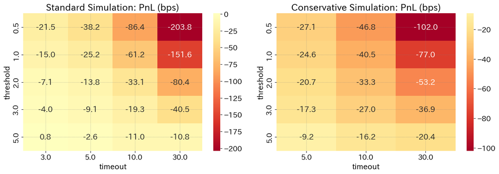

```python
# 保守的 vs 通常のシミュレーション比較

fig, axes = plt.subplots(1, 2, figsize=(14, 5))

# 通常
pivot1 = results_df.pivot(index='threshold', columns='timeout', values='pnl_bps')
sns.heatmap(pivot1, annot=True, fmt='.1f', cmap='RdYlGn', center=0, ax=axes[0])
axes[0].set_title('Standard Simulation: PnL (bps)')

# 保守的
pivot2 = cons_df.pivot(index='threshold', columns='timeout', values='pnl_bps')
sns.heatmap(pivot2, annot=True, fmt='.1f', cmap='RdYlGn', center=0, ax=axes[1])
axes[1].set_title('Conservative Simulation: PnL (bps)')

plt.tight_layout()
plt.show()
```

## 5. 結論とまとめ

```python
# 最終サマリー

print("=" * 80)
print("Maker注文シミュレーション最終結果")
print("=" * 80)

# 通常シミュレーションのベスト
best_std = results_df.loc[results_df['pnl_bps'].idxmax()]
print(f"\n【通常シミュレーション】")
print(f"ベストパラメータ: Threshold={best_std['threshold']}bps, Timeout={best_std['timeout']}s")
print(f"PnL: {best_std['pnl_bps']:.2f} bps")
print(f"約定率: {best_std['fill_rate']:.2%}")
print(f"約定数: {best_std['n_fills']:.0f}")

# 保守的シミュレーションのベスト
best_cons = cons_df.loc[cons_df['pnl_bps'].idxmax()]
print(f"\n【保守的シミュレーション（価格通過のみ）】")
print(f"ベストパラメータ: Threshold={best_cons['threshold']}bps, Timeout={best_cons['timeout']}s")
print(f"PnL: {best_cons['pnl_bps']:.2f} bps")
print(f"約定率: {best_cons['fill_rate']:.2%}")
print(f"約定数: {best_cons['n_fills']:.0f}")

print(f"\n" + "=" * 80)
print("分析期間: 6日間")
print("戦略: BitFlyer Lead-Lag (4秒累積リターン)")
print("注文方式: Maker Only (Best Bid/Ask)")
print("=" * 80)
```

```
================================================================================
Maker注文シミュレーション最終結果
================================================================================

【通常シミュレーション】
ベストパラメータ: Threshold=5.0bps, Timeout=3.0s
PnL: 0.81 bps
約定率: 9.41%
約定数: 898

【保守的シミュレーション（価格通過のみ）】
ベストパラメータ: Threshold=5.0bps, Timeout=5.0s
PnL: -9.23 bps
約定率: 15.67%
約定数: 1446

================================================================================
分析期間: 6日間
戦略: BitFlyer Lead-Lag (4秒累積リターン)
注文方式: Maker Only (Best Bid/Ask)
================================================================================
```